# Differential Gene Expression Analysis

Pan-cancer | Necroptosis, Ferroptosis & Pyroptosis | Unique Genes per RCD Type

Mark Edward M. Gonzales[^1]

Dr. Anish M.S. Shrestha[^2]

## I. Preliminaries

### Loading libraries

```r
library("tidyverse")
library("tibble")
library("msigdbr")
library("ggplot2")
library("TCGAbiolinks")
library("RNAseqQC")
library("DESeq2")
library("ensembldb")
library("purrr")
library("magrittr")
library("vsn")
library("matrixStats")
library("dplyr")
library("grex")
```

## II. Downloading the TCGA gene expression data

Create a function for downloading TCGA gene expression data.

For more detailed documentation, refer to `2. Differential Gene Expression Analysis - TCGA.Rmd`.

```r
GDC_DIR = "../data/public/GDCdata"

query_and_filter_samples <- function(project) {
  query_tumor <- GDCquery(
    project = project,
    data.category = "Transcriptome Profiling",
    data.type = "Gene Expression Quantification",
    experimental.strategy = "RNA-Seq",
    workflow.type = "STAR - Counts",
    access = "open",
    sample.type = "Primary Tumor"
  )
  tumor <- getResults(query_tumor)

  query_normal <- GDCquery(
    project = project,
    data.category = "Transcriptome Profiling",
    data.type = "Gene Expression Quantification",
    experimental.strategy = "RNA-Seq",
    workflow.type = "STAR - Counts",
    access = "open",
    sample.type = "Solid Tissue Normal"
  )
  normal <- getResults(query_normal)

  submitter_ids <- inner_join(tumor, normal, by = "cases.submitter_id") %>%
    dplyr::select(cases.submitter_id)
  tumor <- tumor %>%
    dplyr::filter(cases.submitter_id %in% submitter_ids$cases.submitter_id)
  normal <- normal %>%
    dplyr::filter(cases.submitter_id %in% submitter_ids$cases.submitter_id)

  samples <- rbind(tumor, normal)
  unique(samples$sample_type)

  query_project <- GDCquery(
    project = project,
    data.category = "Transcriptome Profiling",
    data.type = "Gene Expression Quantification",
    experimental.strategy = "RNA-Seq",
    workflow.type = "STAR - Counts",
    access = "open",
    sample.type = c("Solid Tissue Normal", "Primary Tumor"),
    barcode = as.list(samples$sample.submitter_id)
  )

  # If this is your first time running this notebook (i.e., you have not yet downloaded the results of the query in the previous block),
  # uncomment the code block below

  # GDCdownload(
  #   query_coad,
  #   directory = GDC_DIR
  # )

  return(list(samples = samples, query_project = query_project))
}
```

Download the TCGA gene expression data for all the cancer types in TCGA.

Refer to this link for the list of TCGA cancer type abbreviations: https://gdc.cancer.gov/resources-tcga-users/tcga-code-tables/tcga-study-abbreviations

```r
projects <- c(
  "TCGA-LAML", "TCGA-ACC", "TCGA-BLCA", "TCGA-LGG", "TCGA-BRCA",
  "TCGA-CESC", "TCGA-CHOL", "TCGA-COAD", "TCGA-ESCA",
  "TCGA-HNSC", "TCGA-KICH", "TCGA-KIRC",
  "TCGA-KIRP", "TCGA-LIHC", "TCGA-LUAD", "TCGA-LUSC", "TCGA-DLBC",
  "TCGA-MESO", "TCGA-OV", "TCGA-PAAD", "TCGA-PCPG", "TCGA-PRAD",
  "TCGA-READ", "TCGA-SARC", "TCGA-STAD", "TCGA-TGCT",
  "TCGA-THYM", "TCGA-THCA", "TCGA-UCS", "TCGA-UCEC", "TCGA-UVM"
)

with_results_projects <- c()

samples <- list()
project_data <- list()

for (project in projects) {
  result <- tryCatch(
    {
      result <- query_and_filter_samples(project)
      samples[[project]] <- result$samples
      project_data[[project]] <- result$query_project

      with_results_projects <- c(with_results_projects, project)
    },
    error = function(e) {

    }
  )
}
```

Running the code block above should generate and populate a directory named `GDCdata`.

## III. Data preprocessing

Construct the RNA-seq count matrix for each cancer type.

```r
tcga_data <- list()
tcga_matrix <- list()

projects <- with_results_projects
for (project in projects) {
  tcga_data[[project]] <- GDCprepare(
    project_data[[project]],
    directory = GDC_DIR,
    summarizedExperiment = TRUE
  )
}
```

```r
for (project in projects) {
  count_matrix <- assay(tcga_data[[project]], "unstranded")

  # Remove duplicate entries
  count_matrix_df <- data.frame(count_matrix)
  count_matrix_df <- count_matrix_df[!duplicated(count_matrix_df), ]
  count_matrix <- data.matrix(count_matrix_df)
  rownames(count_matrix) <- cleanid(rownames(count_matrix))
  count_matrix <- count_matrix[!(duplicated(rownames(count_matrix)) | duplicated(rownames(count_matrix), fromLast = TRUE)), ]

  tcga_matrix[[project]] <- count_matrix
}
```

Format the `samples` table so that it can be fed as input to DESeq2.

```r
for (project in projects) {
  rownames(samples[[project]]) <- samples[[project]]$cases
  samples[[project]] <- samples[[project]] %>%
    dplyr::select(case = "cases.submitter_id", type = "sample_type")
  samples[[project]]$type <- str_replace(samples[[project]]$type, "Solid Tissue Normal", "normal")
  samples[[project]]$type <- str_replace(samples[[project]]$type, "Primary Tumor", "tumor")
}
```

DESeq2 requires the row names of `samples` should be identical to the column names of `count_matrix`.

```r
for (project in projects) {
  colnames(tcga_matrix[[project]]) <- gsub(x = colnames(tcga_matrix[[project]]), pattern = "\\.", replacement = "-")
  tcga_matrix[[project]] <- tcga_matrix[[project]][, rownames(samples[[project]])]

  # Sanity check
  print(all(colnames(tcga_matrix[[project]]) == rownames(samples[[project]])))
}
```

## IV. Differential gene expression analysis

References:

- Official documentation: https://www.bioconductor.org/packages/release/bioc/vignettes/DESeq2/inst/doc/DESeq2.html
- Good balance of theory and hands-on: https://hbctraining.github.io/DGE_workshop/lessons/04_DGE_DESeq2_analysis.html
- Quality control: https://cran.r-project.org/web/packages/RNAseqQC/vignettes/introduction.html

Construct the `DESeqDataSet` object for each cancer type.

```r
dds_results <- list()

for (project in projects) {
  dds_results[[project]] <- DESeqDataSetFromMatrix(
    countData = tcga_matrix[[project]],
    colData = samples[[project]],
    design = ~type
  )
}
```

### Regulated Cell Death

We obtain the gene sets from RCDdb: https://pmc.ncbi.nlm.nih.gov/articles/PMC11384979/

Download the gene sets by running:

```
wget http://chenyclab.com/RCDdb/download/Necroptosis.csv -P ../data/public/rcd-gene-list/RCDdb/
wget http://chenyclab.com/RCDdb/download/Ferroptosis.csv -P ../data/public/rcd-gene-list/RCDdb/
wget http://chenyclab.com/RCDdb/download/Pyroptosis.csv -P ../data/public/rcd-gene-list/RCDdb/
```

Afterwards, filter the gene sets in order to retain only the genes unique to the RCD type of interest.

This filtering step is handled by a separate Python script and can be performed by running:

```
python 7-get-unique-genes.py --rcd-gene-list-dir ../data/public/rcd-gene-list/RCDdb --output-dir ../data/public/rcd-gene-list/unique-genes/necroptosis-ferroptosis-pyroptosis
```

```r
RCDdb <- "../data/public/rcd-gene-list/unique-genes/necroptosis-ferroptosis-pyroptosis/"
```

Write utility functions for filtering the gene sets, performing differential gene expression analysis, and plotting the results.

```r
filter_gene_set_and_perform_dgea <- function(genes) {
  tcga_rcd <- list()

  for (project in projects) {
    rownames(genes) <- genes$gene_id
    tcga_rcd[[project]] <- tcga_matrix[[project]][rownames(tcga_matrix[[project]]) %in% genes$gene_id, ]
    tcga_rcd[[project]] <- tcga_rcd[[project]][, rownames(samples[[project]])]
  }

  dds_rcd <- list()
  res_rcd <- list()

  for (project in projects) {
    print(project)
    print("=============")
    dds <- DESeqDataSetFromMatrix(
      countData = tcga_rcd[[project]],
      colData = samples[[project]],
      design = ~type
    )
    dds <- filter_genes(dds, min_count = 10)
    dds$type <- relevel(dds$type, ref = "normal")
    dds_rcd[[project]] <- DESeq(dds)
    res_rcd[[project]] <- results(dds_rcd[[project]])
  }

  deseq.bbl.data <- list()

  for (project in projects) {
    deseq.results <- res_rcd[[project]]
    deseq.bbl.data[[project]] <- data.frame(
      row.names = rownames(deseq.results),
      baseMean = deseq.results$baseMean,
      log2FoldChange = deseq.results$log2FoldChange,
      lfcSE = deseq.results$lfcSE,
      stat = deseq.results$stat,
      pvalue = deseq.results$pvalue,
      padj = deseq.results$padj,
      cancer_type = project,
      gene_symbol = genes[rownames(deseq.results), "gene"]
    )
  }

  deseq.bbl.data.combined <- bind_rows(deseq.bbl.data)
  deseq.bbl.data.combined <- dplyr::filter(deseq.bbl.data.combined, abs(log2FoldChange) >= 1.5 & padj < 0.05)

  return(deseq.bbl.data.combined)
}
```

```r
plot_dgea <- function(deseq.bbl.data.combined) {
  sizes <- c("<10^-15" = 4, "10^-10" = 3, "10^-5" = 2, "0.05" = 1)

  deseq.bbl.data.combined <- deseq.bbl.data.combined %>%
    mutate(fdr_category = cut(padj,
      breaks = c(-Inf, 1e-15, 1e-10, 1e-5, 0.05),
      labels = c("<10^-15", "10^-10", "10^-5", "0.05"),
      right = FALSE
    ))

  top_genes <- deseq.bbl.data.combined %>%
    group_by(cancer_type) %>%
    mutate(rank = rank(-abs(log2FoldChange))) %>%
    dplyr::filter(rank <= 10) %>%
    ungroup()

  ggplot(top_genes, aes(y = cancer_type, x = gene_symbol, size = fdr_category, fill = log2FoldChange)) +
    geom_point(alpha = 0.5, shape = 21, color = "black") +
    scale_size_manual(values = sizes) +
    scale_fill_gradient2(low = "blue", mid = "white", high = "red", limits = c(min(deseq.bbl.data.combined$log2FoldChange), max(deseq.bbl.data.combined$log2FoldChange))) +
    theme_minimal() +
    theme(
      axis.text.x = element_text(size = 9, angle = 90, hjust = 1)
    ) +
    theme(legend.position = "bottom") +
    theme(legend.position = "bottom") +
    labs(size = "Adjusted p-value", fill = "log2 FC", y = "Cancer type", x = "Gene")
}
```

#### 1. Necroptosis

Fetch the gene set of interest.

```r
genes <- read.csv(paste0(RCDdb, "Necroptosis.csv"))
print(genes)
```

| deathtype | gene | description | gene_id | gene_biotype | pmid | comment |
| --- | --- | --- | --- | --- | --- | --- |
| Necroptosis | RBCK1 | RANBP2-type and C3HC4-type zinc finger containing 1 | ENSG00000125826.22 | protein_coding | 36248876 | RBCK1 is highly expressed in ccRCC and regulates the immune suppressive microenvironment of tumors. In addition, RBCK1 can also promote chemoresistance and stemness in colorectal cancer. |
| Necroptosis | JAK2 | Janus kinase 2 | ENSG00000096968.14 | protein_coding | 31729527 | The release of CCL2 is necroptosis-dependent. CCL2 released by TAA can activate the Notch signaling pathway through the JAK2/STAT3 pathway, which directly maintains the stemness of MBSCs. |
| Necroptosis | ZBP1 | Z-DNA binding protein 1 | ENSG00000124256.15 | protein_coding | 36917643 | _BP1 is a protein that mediates Necroptosis, interacts with kinase RIPK3, and participates in forming necrosomes. |
| Necroptosis | RNF31 | ring finger protein 31 | ENSG00000092098.18 | protein_coding | 29728512 | RNF31, also known as HOIP, is associated with necroptosis. It is a key enzyme in the ribonuclease polymerase-induced cell death pathway. |
| Necroptosis | IFNB1 | interferon beta 1 | ENSG00000171855.7 | protein_coding | 23601685 | The relationship between IFNB1 and Necroptosis is that Poly IC stimulation of dendritic cells (DCs) induces Necroptosis through the signaling pathway mediated by IPS-1 and RIP-1, while also promoting … |
| Necroptosis | TRAF5 | TNF receptor associated factor 5 | ENSG00000082512.15 | protein_coding | 33555197 | METTL3 enabled OX resistance in CRC cells by inhibiting TRAF5-mediated Necroptosis. |
| Necroptosis | BIRC2 | baculoviral IAP repeat containing 2 | ENSG00000110330.10 | protein_coding | 27469115 | Approximately 30% of HNSCC patients exhibit FADD/BIRC2 genomic amplification, which is correlated with HPV-negative HNSCC and worse prognosis. |
| Necroptosis | TRAF2 | TNF receptor associated factor 2 | ENSG00000127191.18 | protein_coding | 25882049 | TRAF2 inhibits Necroptosis by modulating the signaling complex containing receptor-interacting protein kinases RIPK1 and RIPK3 (the necrosome) and mixed lineage kinase-domain-like (MLKL), which drive … |
| Necroptosis | BCL2 | BCL2 apoptosis regulator | ENSG00000171791.14 | protein_coding | 31634424 | Fisetin can reduce the expression of the anti-apoptotic protein BCL2 and increase the levels of pro-apoptotic proteins Bax, caspase-3, and PARP in HepG2 cells, inducing cell death through apoptosis pa… |
| Necroptosis | STAT4 | signal transducer and activator of transcription 4 | ENSG00000138378.19 | protein_coding | 36518671 | The STAT4 gene is mentioned to be related to Necroptosis. STAT4 deficiency has a protective effect against neointima formation following arterial injury in mice and is also involved in the development… |

[output cut: 44 more lines]

```r
genes$gene_id <- cleanid(genes$gene_id)
genes <- distinct(genes, gene_id, .keep_all = TRUE)
genes <- subset(genes, gene_id != "")
genes
```

|  | deathtype | gene | description | gene_id | gene_biotype | pmid | comment |
| --- | --- | --- | --- | --- | --- | --- | --- |
| 1 | Necroptosis | RBCK1 | RANBP2-type and C3HC4-type zinc finger containing 1 | ENSG00000125826 | protein_coding | 36248876 | RBCK1 is highly expressed in ccRCC and regulates the immune suppressive microenvironment of tumors. In addition, RBCK1 can also promote chemoresistance and stemness in colorectal cancer. |
| 2 | Necroptosis | JAK2 | Janus kinase 2 | ENSG00000096968 | protein_coding | 31729527 | The release of CCL2 is necroptosis-dependent. CCL2 released by TAA can activate the Notch signaling pathway through the JAK2/STAT3 pathway, which directly maintains the stemness of MBSCs. |
| 3 | Necroptosis | ZBP1 | Z-DNA binding protein 1 | ENSG00000124256 | protein_coding | 36917643 | _BP1 is a protein that mediates Necroptosis, interacts with kinase RIPK3, and participates in forming necrosomes. |
| 4 | Necroptosis | RNF31 | ring finger protein 31 | ENSG00000092098 | protein_coding | 29728512 | RNF31, also known as HOIP, is associated with necroptosis. It is a key enzyme in the ribonuclease polymerase-induced cell death pathway. |
| 5 | Necroptosis | IFNB1 | interferon beta 1 | ENSG00000171855 | protein_coding | 23601685 | The relationship between IFNB1 and Necroptosis is that Poly IC stimulation of dendritic cells (DCs) induces Necroptosis through the signaling pathway mediated by IPS-1 and RIP-1, while also promoting … |
| 6 | Necroptosis | TRAF5 | TNF receptor associated factor 5 | ENSG00000082512 | protein_coding | 33555197 | METTL3 enabled OX resistance in CRC cells by inhibiting TRAF5-mediated Necroptosis. |
| 7 | Necroptosis | BIRC2 | baculoviral IAP repeat containing 2 | ENSG00000110330 | protein_coding | 27469115 | Approximately 30% of HNSCC patients exhibit FADD/BIRC2 genomic amplification, which is correlated with HPV-negative HNSCC and worse prognosis. |
| 8 | Necroptosis | TRAF2 | TNF receptor associated factor 2 | ENSG00000127191 | protein_coding | 25882049 | TRAF2 inhibits Necroptosis by modulating the signaling complex containing receptor-interacting protein kinases RIPK1 and RIPK3 (the necrosome) and mixed lineage kinase-domain-like (MLKL), which drive … |
| 9 | Necroptosis | BCL2 | BCL2 apoptosis regulator | ENSG00000171791 | protein_coding | 31634424 | Fisetin can reduce the expression of the anti-apoptotic protein BCL2 and increase the levels of pro-apoptotic proteins Bax, caspase-3, and PARP in HepG2 cells, inducing cell death through apoptosis pa… |
| 10 | Necroptosis | STAT4 | signal transducer and activator of transcription 4 | ENSG00000138378 | protein_coding | 36518671 | The STAT4 gene is mentioned to be related to Necroptosis. STAT4 deficiency has a protective effect against neointima formation following arterial injury in mice and is also involved in the development… |

[output cut: 44 more lines]

Filter the genes to include only those in the gene set of interest, and then perform differential gene expression analysis.

```r
deseq.bbl.data.combined <- filter_gene_set_and_perform_dgea(genes)
```

```
[1] "TCGA-BLCA"
[1] "============="
```

```
[1] "TCGA-BRCA"
[1] "============="
```

```
[1] "TCGA-CESC"
[1] "============="
```

```
[1] "TCGA-CHOL"
[1] "============="
```

```
[1] "TCGA-COAD"
[1] "============="
```

```
[1] "TCGA-ESCA"
[1] "============="
```

```
[1] "TCGA-HNSC"
[1] "============="
```

```
[1] "TCGA-KICH"
[1] "============="
```

```
[1] "TCGA-KIRC"
[1] "============="
```

```
[1] "TCGA-KIRP"
[1] "============="
```

```
[1] "TCGA-LIHC"
[1] "============="
```

```
[1] "TCGA-LUAD"
[1] "============="
```

```
[1] "TCGA-LUSC"
[1] "============="
```

```
[1] "TCGA-PAAD"
[1] "============="
```

```
[1] "TCGA-PCPG"
[1] "============="
```

```
[1] "TCGA-PRAD"
[1] "============="
```

```
[1] "TCGA-READ"
[1] "============="
```

```
[1] "TCGA-SARC"
[1] "============="
```

```
[1] "TCGA-STAD"
[1] "============="
```

```
[1] "TCGA-THYM"
[1] "============="
```

```
[1] "TCGA-THCA"
[1] "============="
```

```
[1] "TCGA-UCEC"
[1] "============="
```

```r
deseq.bbl.data.combined
```

|  | baseMean | log2FoldChange | lfcSE | stat | pvalue | padj | cancer_type | gene_symbol |
| --- | --- | --- | --- | --- | --- | --- | --- | --- |
| ENSG00000023445...1 | 1438.231634 | -1.703318 | 0.3006694 | -5.665085 | 1.469517e-08 | 1.947109e-07 | TCGA-BLCA | BIRC3 |
| ENSG00000070808...2 | 195.580878 | -4.303989 | 0.4994684 | -8.617140 | 6.864725e-18 | 3.638304e-16 | TCGA-BLCA | CAMK2A |
| ENSG00000137033...3 | 1492.793519 | -2.884279 | 0.4126659 | -6.989382 | 2.760994e-12 | 7.316635e-11 | TCGA-BLCA | IL33 |
| ENSG00000137033...4 | 2693.528924 | -2.462670 | 0.1775602 | -13.869491 | 9.696182e-44 | 5.235938e-42 | TCGA-BRCA | IL33 |
| ENSG00000171855 | 1.459902 | 3.270370 | 0.4586357 | 7.130648 | 9.989778e-13 | 2.996933e-12 | TCGA-BRCA | IFNB1 |
| ENSG00000115415...6 | 11811.946809 | 1.886577 | 0.5073580 | 3.718434 | 2.004620e-04 | 3.541496e-03 | TCGA-CESC | STAT1 |
| ENSG00000124256...7 | 192.798664 | 2.694741 | 0.8557801 | 3.148871 | 1.639025e-03 | 1.737366e-02 | TCGA-CESC | ZBP1 |
| ENSG00000137033...8 | 3437.457727 | -5.835912 | 0.6130911 | -9.518834 | 1.751337e-21 | 9.282086e-20 | TCGA-CESC | IL33 |
| ENSG00000171791...9 | 3320.769064 | -3.479870 | 0.6436446 | -5.406509 | 6.426502e-08 | 1.703023e-06 | TCGA-CESC | BCL2 |
| ENSG00000023445...10 | 2568.938523 | 1.999093 | 0.4711623 | 4.242897 | 2.206527e-05 | 8.995840e-05 | TCGA-CHOL | BIRC3 |

[output cut: 56 more lines]

Plot the results.

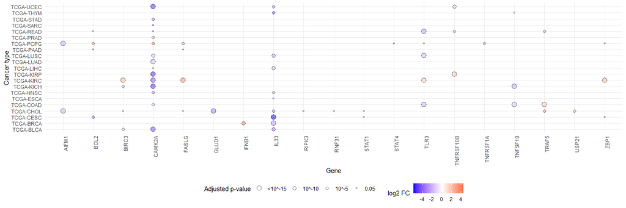

```r
plot_dgea(deseq.bbl.data.combined)
```

#### 2. Ferroptosis

Fetch the gene set of interest.

```r
genes <- read.csv(paste0(RCDdb, "Ferroptosis.csv"))
genes$gene_id <- cleanid(genes$gene_id)
genes <- distinct(genes, gene_id, .keep_all = TRUE)
genes <- subset(genes, gene_id != "")
genes
```

|  | deathtype | gene | description | gene_id | gene_biotype | pmid | comment |
| --- | --- | --- | --- | --- | --- | --- | --- |
| 1 | Ferroptosis | MIR212 | microRNA 212 | ENSG00000267195 | miRNA | 31533781 | miR-212-5p was significantly downregulated after TBI and functionally suppressed ferroptosis by directly targeting Ptgs2. Administration of miR-212-5p in CCI mice significantly improved learning and s… |
| 2 | Ferroptosis | NR5A2 | nuclear receptor subfamily 5 group A member 2 | ENSG00000116833 | protein_coding | 32536370 | NCOA3 as a coactivator synergized with NR5A2 to prevent BETi induced ferroptosis. |
| 3 | Ferroptosis | TFAM | transcription factor A, mitochondrial | ENSG00000108064 | protein_coding | 32186434 | Zalcitabine-induced TFAM degradation promotes ferroptosis. |
| 4 | Ferroptosis | CREB5 | cAMP responsive element binding protein 5 | ENSG00000146592 | protein_coding | 33846793 | CREB stimulates GPX4 transcription to inhibit ferroptosis in lung adenocarcinoma. |
| 5 | Ferroptosis | NOS2 | nitric oxide synthase 2 | ENSG00000007171 | protein_coding | 32080625 | Knockdown (KD) of iNOS caused increased sensitivity of M1 RAW 264.7 macrophages and EOC 20 cells to RSL3 induced death that was effectively suppressed by Fer-1. |
| 6 | Ferroptosis | HULC | hepatocellular carcinoma up-regulated long non-coding RNA | ENSG00000285219 | lncRNA | 35615577 | HULC was found to function as a ceRNA of miR-3200-5p, and miR-3200-5p regulates ferroptosis by targeting ATF4, resulting in the inhibition of proliferation and metastasis within HCC cells. In summary,… |
| 7 | Ferroptosis | PLXNB2 | plexin B2 | ENSG00000196576 | protein_coding | 36423520 | Although HDLBP or lncFAL could not regulate the GPX4 antioxidant signalling pathway, lncFAL reduced ferroptosis vulnerability by directly binding to ferroptosis suppressor protein 1 (FSP1) and competi… |
| 8 | Ferroptosis | KIF20A | kinesin family member 20A | ENSG00000112984 | protein_coding | 33819186 | High KIF20A expression in resistant CRC cell line suppressed the intracellular ferroptosis process. |
| 9 | Ferroptosis | TIMP1 | TIMP metallopeptidase inhibitor 1 | ENSG00000102265 | protein_coding | 34938604 | Silencing TIMP1 inhibits CMEC ferroptosis by downregulation of TFR-1. |
| 10 | Ferroptosis | MIR615 | microRNA 615 | ENSG00000207571 | miRNA | 36427803 | Propofol upregulated miR-744-5p/miR-615-3p to inhibit GPX4 transcription. Upregulation of GPX4 or downregulation of miR-744-5p/miR-615-3p attenuated the inhibitory effect of propofol on CR to Cis. In … |

[output cut: 516 more lines]

Filter the genes to include only those in the gene set of interest, and then perform differential gene expression analysis.

```r
deseq.bbl.data.combined <- filter_gene_set_and_perform_dgea(genes)
```

```
[1] "TCGA-BLCA"
[1] "============="
```

```
[1] "TCGA-BRCA"
[1] "============="
```

```
[1] "TCGA-CESC"
[1] "============="
```

```
[1] "TCGA-CHOL"
[1] "============="
```

```
[1] "TCGA-COAD"
[1] "============="
```

```
[1] "TCGA-ESCA"
[1] "============="
```

```
[1] "TCGA-HNSC"
[1] "============="
```

```
[1] "TCGA-KICH"
[1] "============="
```

```
[1] "TCGA-KIRC"
[1] "============="
```

```
[1] "TCGA-KIRP"
[1] "============="
```

```
[1] "TCGA-LIHC"
[1] "============="
```

```
[1] "TCGA-LUAD"
[1] "============="
```

```
[1] "TCGA-LUSC"
[1] "============="
```

```
[1] "TCGA-PAAD"
[1] "============="
```

```
[1] "TCGA-PCPG"
[1] "============="
```

```
[1] "TCGA-PRAD"
[1] "============="
```

```
[1] "TCGA-READ"
[1] "============="
```

```
[1] "TCGA-SARC"
[1] "============="
```

```
[1] "TCGA-STAD"
[1] "============="
```

```
[1] "TCGA-THYM"
[1] "============="
```

```
[1] "TCGA-THCA"
[1] "============="
```

```
[1] "TCGA-UCEC"
[1] "============="
```

```r
deseq.bbl.data.combined
```

|  | baseMean | log2FoldChange | lfcSE | stat | pvalue | padj | cancer_type | gene_symbol |
| --- | --- | --- | --- | --- | --- | --- | --- | --- |
| ENSG00000004799...1 | 7.538910e+03 | -3.566137 | 0.44477576 | -8.017831 | 1.076290e-15 | 9.299147e-14 | TCGA-BLCA | PDK4 |
| ENSG00000018408...2 | 5.967735e+03 | -2.121860 | 0.31327327 | -6.773193 | 1.259703e-11 | 6.046576e-10 | TCGA-BLCA | WWTR1 |
| ENSG00000047457...3 | 2.133056e+03 | 2.559832 | 0.70569066 | 3.627413 | 2.862747e-04 | 1.189141e-03 | TCGA-BLCA | CP |
| ENSG00000072274...4 | 1.231476e+04 | 1.922899 | 0.30406348 | 6.324006 | 2.548670e-10 | 6.881409e-09 | TCGA-BLCA | TFRC |
| ENSG00000081189...5 | 1.338222e+03 | -2.041348 | 0.28927933 | -7.056668 | 1.705427e-12 | 9.209306e-11 | TCGA-BLCA | MEF2C |
| ENSG00000090889...6 | 9.509968e+02 | 2.360685 | 0.40150759 | 5.879552 | 4.113787e-09 | 7.108623e-08 | TCGA-BLCA | KIF4A |
| ENSG00000091513...7 | 7.142632e+01 | -1.972621 | 0.55224843 | -3.571981 | 3.542915e-04 | 1.414717e-03 | TCGA-BLCA | TF |
| ENSG00000099194...8 | 2.114981e+04 | 2.535264 | 0.42840518 | 5.917912 | 3.260533e-09 | 6.124132e-08 | TCGA-BLCA | SCD |
| ENSG00000100253...9 | 5.977368e+00 | 2.146862 | 0.75462912 | 2.844924 | 4.442204e-03 | 1.296643e-02 | TCGA-BLCA | MIOX |
| ENSG00000105974...10 | 1.254047e+04 | -2.516877 | 0.35582658 | -7.073324 | 1.512655e-12 | 9.209306e-11 | TCGA-BLCA | CAV1 |

[output cut: 990 more lines]

Plot the results.

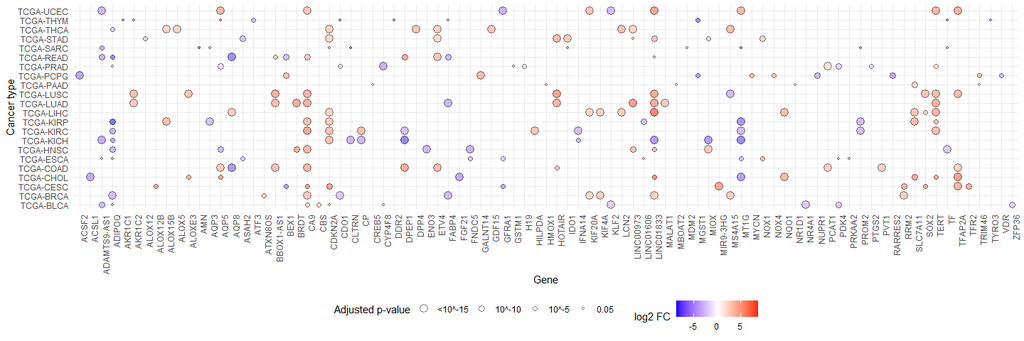

```r
plot_dgea(deseq.bbl.data.combined)
```

#### 3. Pyroptosis

Fetch the gene set of interest.

```r
genes <- read.csv(paste0(RCDdb, "Pyroptosis.csv"))
genes$gene_id <- cleanid(genes$gene_id)
genes <- distinct(genes, gene_id, .keep_all = TRUE)
genes <- subset(genes, gene_id != "")
genes
```

|  | deathtype | gene | description | gene_id | gene_biotype | pmid | comment |
| --- | --- | --- | --- | --- | --- | --- | --- |
| 1 | Pyroptosis | CHMP7 | charged multivesicular body protein 7 | ENSG00000147457 | protein_coding | 36818162 | CHMP7 gene exhibited copy number variations and played a role in pyroptosis in skin cutaneous melanoma patients. |
| 2 | Pyroptosis | GSDMC | gasdermin C | ENSG00000147697 | protein_coding | 32929201 | GSDMC mediates tumour necrosis following caspase-8 activation in tumour cells and provides valuable insights into the pyroptosis pathway in cancer cells in which the specific expression and distinct c… |
| 3 | Pyroptosis | ELANE | elastase, neutrophil expressed | ENSG00000197561 | protein_coding | 29539421 | ELANE is an important protease, which is shown in this paper to promote cell death by cleaving Gasdermin D in neutrophils. This type of cell death is achieved through a mechanism called pyroptosis whi… |
| 4 | Pyroptosis | IRF1 | interferon regulatory factor 1 | ENSG00000125347 | protein_coding | 36384204 | IRF1 is shown to be involved in pyroptosis by promoting NLRP3 inflammasome-mediated endothelial cell pyroptosis and the development of atherosclerosis. IRF1 enhances the activation of the NLRP3 inflam… |
| 5 | Pyroptosis | CYCS | cytochrome c, somatic | ENSG00000172115 | protein_coding | 37077542 | Pyroptosis is a newly discovered type of programmed cell death, and CYCS can be involved in the apoptotic process of pyroptosis. |
| 6 | Pyroptosis | GSDMA | gasdermin A | ENSG00000167914 | protein_coding | 35110732 | GAS cysteine protease SpeB triggers keratinocyte pyroptosis by cleaving GSDMA protein after Gln246, unleashing an active N-terminal fragment that triggers pyroptosis and recruits immune cells to infec… |
| 7 | Pyroptosis | CASP4 | caspase 4 | ENSG00000196954 | protein_coding | 32109412 | Site-specific autoprocessing of Caspase-4/11 generates a p10 product that binds with high affinity to the GSDMD-C domain, facilitating cleavage of GSDMD and inducing Pyroptosis. Crystal structures of … |
| 8 | Pyroptosis | BAK1 | BCL2 antagonist/killer 1 | ENSG00000030110 | protein_coding | 34656686 | Chemotherapy drugs PTX+DDP can induce both apoptosis and Pyroptosis in breast cancer cells by acting on the BAK/BAX-caspase-3-GSDME pathway. |
| 9 | Pyroptosis | NOD1 | nucleotide binding oligomerization domain containing 1 | ENSG00000106100 | protein_coding | 34226539 | NOD1 is a Nod-like receptor protein that recognizes cell wall breakdown products caused by pathogenic bacteria and triggers an inflammatory response.NOD1 was found to be a prognostic factor related to… |
| 10 | Pyroptosis | NLRP7 | NLR family pyrin domain containing 7 | ENSG00000167634 | protein_coding | 34021586 | The activation of inflammasomes is responsible for the release of pro-inflammatory cytokines and the induction of a specialized form of inflammatory cell death. Inappropriate inflammasome responses du… |

[output cut: 23 more lines]

Filter the genes to include only those in the gene set of interest, and then perform differential gene expression analysis.

```r
deseq.bbl.data.combined <- filter_gene_set_and_perform_dgea(genes)
```

```
[1] "TCGA-BLCA"
[1] "============="
```

```
[1] "TCGA-BRCA"
[1] "============="
```

```
[1] "TCGA-CESC"
[1] "============="
```

```
[1] "TCGA-CHOL"
[1] "============="
```

```
[1] "TCGA-COAD"
[1] "============="
```

```
[1] "TCGA-ESCA"
[1] "============="
```

```
[1] "TCGA-HNSC"
[1] "============="
```

```
[1] "TCGA-KICH"
[1] "============="
```

```
[1] "TCGA-KIRC"
[1] "============="
```

```
[1] "TCGA-KIRP"
[1] "============="
```

```
[1] "TCGA-LIHC"
[1] "============="
```

```
[1] "TCGA-LUAD"
[1] "============="
```

```
[1] "TCGA-LUSC"
[1] "============="
```

```
[1] "TCGA-PAAD"
[1] "============="
```

```
[1] "TCGA-PCPG"
[1] "============="
```

```
[1] "TCGA-PRAD"
[1] "============="
```

```
[1] "TCGA-READ"
[1] "============="
```

```
[1] "TCGA-SARC"
[1] "============="
```

```
[1] "TCGA-STAD"
[1] "============="
```

```
[1] "TCGA-THYM"
[1] "============="
```

```
[1] "TCGA-THCA"
[1] "============="
```

```
[1] "TCGA-UCEC"
[1] "============="
```

```r
deseq.bbl.data.combined
```

|  | baseMean | log2FoldChange | lfcSE | stat | pvalue | padj | cancer_type | gene_symbol |
| --- | --- | --- | --- | --- | --- | --- | --- | --- |
| ENSG00000137757...1 | 7.070179 | 1.704193 | 0.5531632 | 3.080813 | 2.064360e-03 | 9.731981e-03 | TCGA-BLCA | CASP5 |
| ENSG00000167634...2 | 51.564530 | 3.247837 | 0.6617279 | 4.908115 | 9.195608e-07 | 1.011517e-05 | TCGA-BLCA | NLRP7 |
| ENSG00000197561...3 | 26.677395 | -4.061493 | 0.4794283 | -8.471535 | 2.421800e-17 | 7.991941e-16 | TCGA-BLCA | ELANE |
| ENSG00000147697...4 | 135.729319 | 1.654596 | 0.2287886 | 7.231984 | 4.759877e-13 | 1.208276e-12 | TCGA-BRCA | GSDMC |
| ENSG00000163568...5 | 71.544257 | 1.552665 | 0.1731999 | 8.964586 | 3.114483e-19 | 9.343449e-19 | TCGA-BRCA | AIM2 |
| ENSG00000167207...6 | 369.926529 | 1.640946 | 0.1334821 | 12.293375 | 9.831362e-35 | 8.110873e-34 | TCGA-BRCA | NOD2 |
| ENSG00000197561...7 | 17.388005 | -3.231344 | 0.1962599 | -16.464614 | 6.588127e-61 | 2.174082e-59 | TCGA-BRCA | ELANE |
| ENSG00000030110...8 | 1740.865612 | 1.858200 | 0.5671645 | 3.276299 | 1.051772e-03 | 5.434157e-03 | TCGA-CESC | BAK1 |
| ENSG00000073605 | 1110.436122 | 2.659618 | 0.6943551 | 3.830343 | 1.279650e-04 | 9.917286e-04 | TCGA-CESC | GSDMB |
| ENSG00000100453...10 | 441.730658 | 2.857846 | 0.6916952 | 4.131655 | 3.601600e-05 | 3.721654e-04 | TCGA-CESC | GZMB |

[output cut: 85 more lines]

Plot the results.

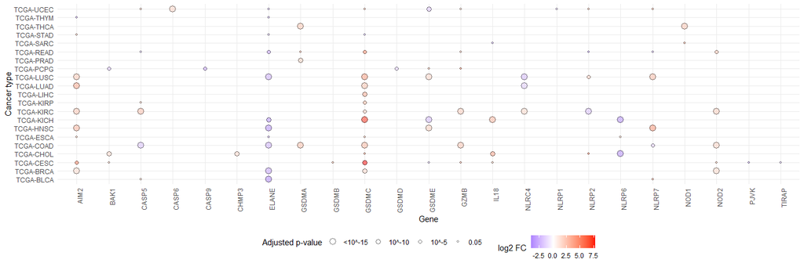

```r
plot_dgea(deseq.bbl.data.combined)
```

[^1]: De La Salle University, Manila, Philippines, gonzales.markedward@gmail.com
[^2]: De La Salle University, Manila, Philippines, anish.shrestha@dlsu.edu.ph